# ANOVA pt. III: Factorial Designs

Tehran Davis

11/9/2017

Note that this week’s vignette assumes you have the following packages:

```r
pacman::p_load(agricolae,afex,cowplot,ggplot2,dplyr,plyr,psych)
```

In this weeks vignette we are simply building upon the previous two weeks coverage of [One-way ANOVA](https://tehjespah.github.io/teaching/PSYC7014/Vignettes/ANOVA/) and [multiple comparisons](https://tehjespah.github.io/teaching/PSYC7014/Vignettes/MultComparisons/). I’m assuming you’ve taken a look at all of the assigned material related to these topics. This week we up the ante by introducing more complex ANOVA models, aka factorial design. As we have discussed, a factorial ANOVA design is required (well, for the purposes of this course) when your experimental design has more than one IV. Our examples for this week focus on situations involving two IVs, however, what is said here applies for more complex designs involving 3, 4, 5, or however many IV’s you want to consider. Well, maybe not however many… as we well see this week and the next, the more IVs you include in your analysis, the more difficult interpreting your results becomes. This is especially true if you have interaction effects running all over the place. But perhaps I’m getting a little bit ahead of myself. Let’s just way I wouldn’t recommend including more than 3 or 4 IVs in your ANOVA at a single time and for now leave it at that.

Relevant readings for the week include Howell Ch. 13 (theory) and Field Ch. 12 (theory and practical analysis in `R`).

# Main effects, main effects, and interactions… oh my!

When we are performing a factorial ANOVA we are performing a series of independent comparisons of means as a function of our IVs (this assumption of independence is one of the reasons that we don’t typically concern ourselves with adjusting our p-values in the omnibus factorial ANOVA). For any given number of IVs, or **factors**, the ANOVA runs a separate One-way ANOVA analysis test for a **main effect** of that factor on the data—that is “do means grouped by levels within that factor differ from one another **not taking into consideration the influence of any of the other IVs**. Our tests for interactions **do** consider the possibility that our factors influence one another—that is,”do the differences that are observed in one factor depend on the intersecting level of another?"

For the sake of simplicity, we will start with a 2 × 2 ANOVA and work our way up by extending the data set. Given our naming conventions, saying that we have a 2 × 2 ANOVA indicates that there are 2 IVs and each has 2 levels. A 2 × 3 ANOVA indicates that there are 2 IVs, and that one IV has 2 levels and the other has 3 levels; a 2 × 3 × 4 ANOVA indicates that we have 3 IVs, the first has 2 levels, the second has 3 levels, and the third has 4 levels.

Our example ANOVA comes from Howell (13.5), testing the effects of smoking on performance in different types of *putatively* information processing tasks. There were 3 types of cognitive tasks: the first, a pattern recognition task where participants had to locate a target on a screen; the second, a cognitive task where participants had to read a passage and recall bits of information from that passage later; and the third, participants performed a driving simulation. Three groups of smokers were recruited— those that were actively smoking prior to and during the experiment; those that were smokers, but did not smoke 3 hours prior to the experiment; and finally non-smokers. As this is a between design, each participants only completed one of the cognitive tasks.

## Example 2×2

Let’s grab the data from Howell’s website. Note that for now we are going to ignore the covar column:

```r
dataset <- read.table("https://www.uvm.edu/~dhowell/methods8/DataFiles/Sec13-5.dat", header=T)

dataset$Smkgrp <- mapvalues(dataset$Smkgrp, from = c(1,2,3), to = c("Nonsmoking","Delayed","Active")) %>% as.factor()

dataset$Task <- mapvalues(dataset$Task, from = c(1,2,3),to = c("Pattern Recognition", "Cognitive", "Driving Simulation")) %>% as.factor()

summary(dataset)
```

```
##                   Task           Smkgrp       score           covar
##  Cognitive          :45   Active    :45   Min.   : 0.00   Min.   : 64.0
##  Driving Simulation :45   Delayed   :45   1st Qu.: 6.00   1st Qu.: 99.0
##  Pattern Recognition:45   Nonsmoking:45   Median :11.00   Median :111.0
##                                           Mean   :18.26   Mean   :112.5
##                                           3rd Qu.:26.00   3rd Qu.:128.0
##                                           Max.   :75.00   Max.   :191.0
```

```r
# subsetting the data. Remember that "!=" means "does not equal"; "&" suggests that both cases must be met, so

dataset_2by2 <- subset(dataset,subset = Smkgrp!="Delayed" & Task!="Cognitive")

# getting a summary of dataset_2by2:
summary(dataset_2by2)
```

```
##                   Task           Smkgrp       score           covar
##  Cognitive          : 0   Active    :30   Min.   : 0.00   Min.   : 64.00
##  Driving Simulation :30   Delayed   : 0   1st Qu.: 2.75   1st Qu.: 98.75
##  Pattern Recognition:30   Nonsmoking:30   Median : 8.00   Median :111.00
##                                           Mean   : 7.90   Mean   :110.73
##                                           3rd Qu.:11.00   3rd Qu.:123.00
##                                           Max.   :22.00   Max.   :168.00
```

You may notice from the summary above that the groups that were dropped “Delayed” smokers and “Cognitive” task still show up in the `summary`, albeit now with 0 instances (you’ll also notice that the remaining groups decreased in number, can you figure out why?). In most cases, `R` notices this an will automatically drop these factors in our subsequent analyses. However, if needed, these factors can be dropped by invoking the `droplevels()`function like so:

```r
dataset_2by2$Smkgrp <- droplevels(dataset_2by2$Smkgrp)
dataset_2by2$Task <- droplevels(dataset_2by2$Task)
```

## Making sense of plots

Let’s go ahead and plot the data using a line plot with 95% CI error bars (building from the examples [here](https://tehjespah.github.io/teaching/PSYC7014/Vignettes/APA/figures/)). Note that I’m just going to use `theme_cowplot()` to generate a clean looking plot for me. Note that these plots (up until the last section) are not APA-complete!!!!

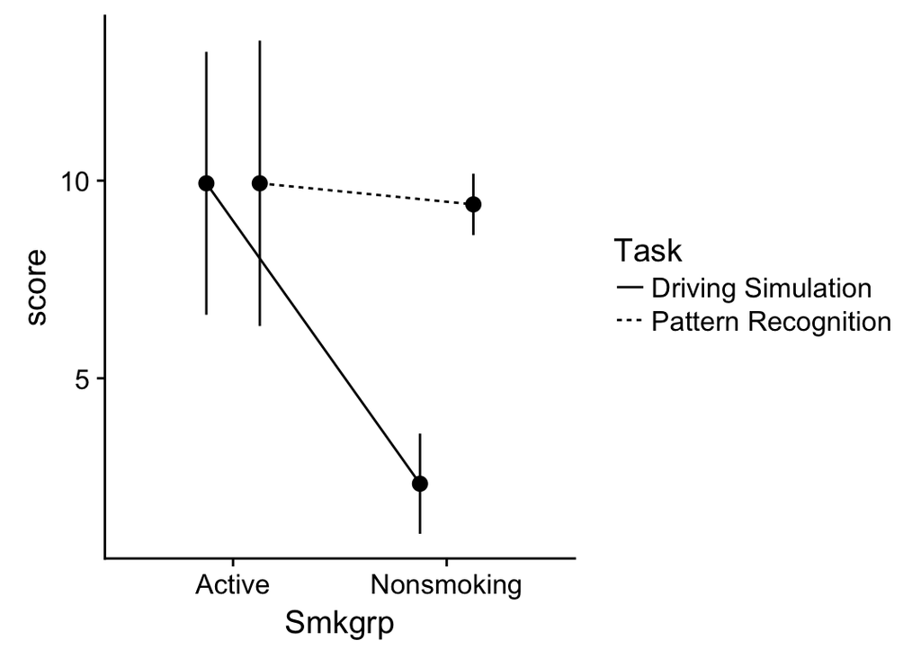

```r
p <- interaction_p <- ggplot2::ggplot(data = dataset_2by2, mapping=aes(x=Smkgrp,y=score,group=Task))

interaction_p <- interaction_p + stat_summary(geom="pointrange",fun.data = "mean_cl_normal", position=position_dodge(.5)) +
  stat_summary(geom = "line", fun.y = "mean", position=position_dodge(.5), aes(linetype=Task)) +
  theme_cowplot()

show(interaction_p)
```

### Interaction plots

What we have created above is known as an interaction plot where the plotted data take into consideration the influence of each of the IVs on one another—in this case the mean and CI of each smoking group (Active v. Nonsmoking) as a function of Task (Driving Simulation v. Pattern Recognition). A brief inspection of the plot can be quite informative. Let’s start with the interaction—FWIW **you should always start with the interaction**. Since this is an “interaction” plot, often a quick visual inspection will allow is to predict whether our subsequent ANOVA will likely yield an interaction effect (it’s good practice to plot *before* running your ANOVA. A simple rule of thumb is that if you see the lines converging or intersecting then more than likely an interaction is present (whether its significant is another question). You might think that this rule of thumb is useful if you use a line plot, and well, you’d be right. What about a bar plot or box plot you ask?

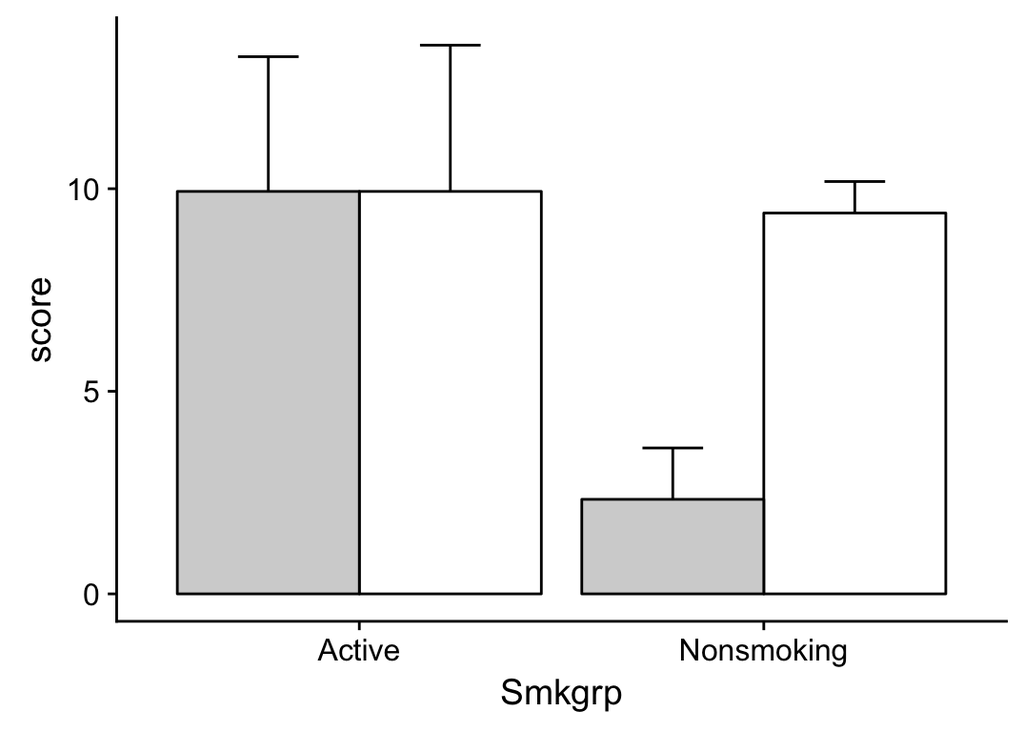

```r
bar_p <- p +
    stat_summary(geom="errorbar", width=.3, fun.data = "mean_cl_normal", position = position_dodge(.9)) +
  stat_summary(geom = "bar",fun.y = "mean",color="black", aes(fill=Task), position=position_dodge(.9)) +
  theme(legend.position="none") +
  scale_fill_manual(values = c("light grey", "white"))

show(bar_p)
```

```r
box_mean <- function(x) {
  r <- quantile(x, probs = c(0.025, 0.25, 0.5, 0.75, 0.975))
  # replace median with mean
  r[3] <- mean(x)
  names(r) <- c("ymin", "lower", "middle", "upper", "ymax")
  r
}

# Add points outside of whiskers
box_out <- function(x) {
  subset(x, x < quantile(x,probs=0.025) | quantile(x,probs=0.975) < x)
}

box_p <- p +
  stat_summary(fun.data = box_mean, size=.5, color="black", geom="boxplot", position=position_dodge(.9), aes(fill=Task)) +
  theme(legend.position="none") +
  scale_fill_manual(values = c("light grey", "white"))
```

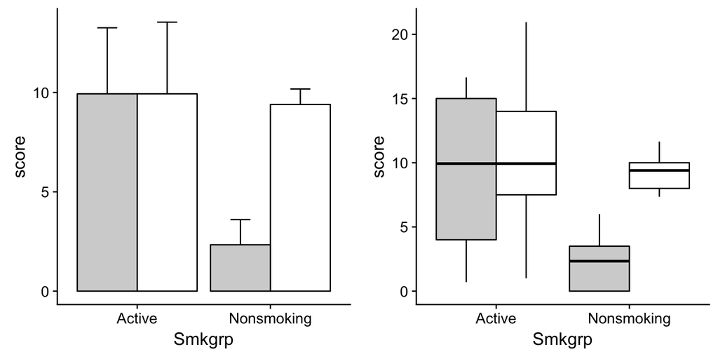

```r
plot_grid(bar_p,box_p)
```

Note that the grey fills above are the “Driving Simulation” group and the white are the “Pattern Recognition”. In both cases just take a look at the means that are grouped together. If the relative difference between grouped means changes as you make from one category on the x axis to the next, you likely have an interaction. Note that this is a general rule of thumb and applies to the line plots as well (the reason that the lines intersect is because of these sorts of changes). In this case, the means on the “Active” grouping are nearly identical, while the means in the “Nonsmoking”" grouping are much further apart. So likely interaction.

### Main effects

If we wanted we could also create separate plots related to our mean effects. These plots would look something like this:

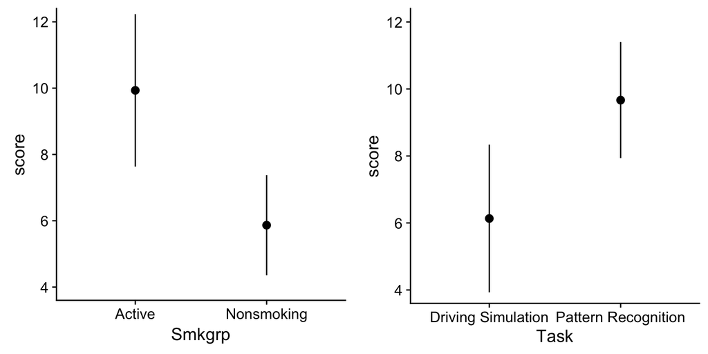

```r
Smoke_p <- ggplot2::ggplot(data = dataset_2by2, mapping=aes(x=Smkgrp,y=score)) +

  stat_summary(geom="pointrange",fun.data = "mean_cl_normal", position=position_dodge(0)) +
  stat_summary(geom = "line", fun.y = "mean", position=position_dodge(0)) +
  coord_cartesian(ylim=c(4,12)) +
  theme_cowplot()

Task_p <- ggplot2::ggplot(data = dataset_2by2, mapping=aes(x=Task,y=score)) +

  stat_summary(geom="pointrange",fun.data = "mean_cl_normal", position=position_dodge(0)) +
  stat_summary(geom = "line", fun.y = "mean", position=position_dodge(0)) +
  coord_cartesian(ylim=c(4,12)) +
  theme_cowplot()

plot_grid(Smoke_p,Task_p)
```

and would take a look at changes due to each IV without considering the other. Here we might infer that there is a main effect for both of our IVs. That said, the interaction plot is useful as well.

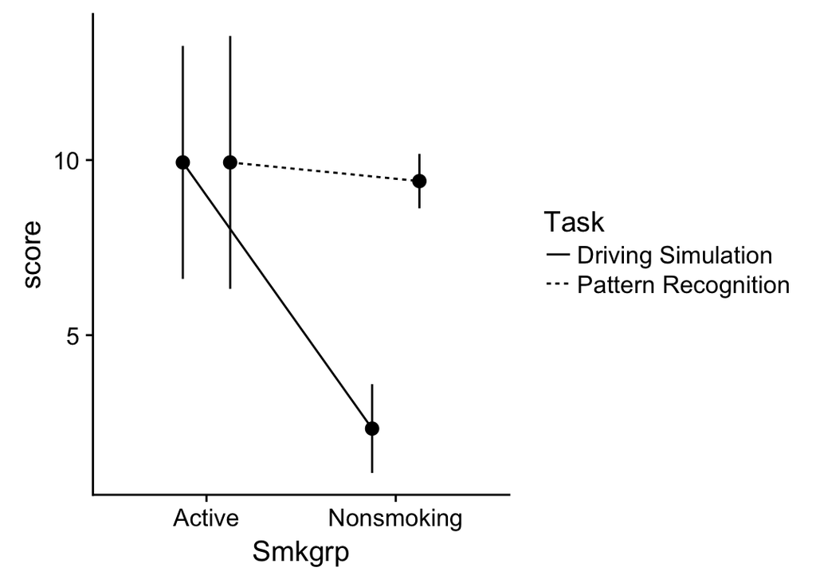

```r
show(interaction_p)
```

Here, to infer whether there might be main effects we can imagine where the means would be if we collapsed our grouped plots (this is exactly what the main effects take a look at). To help with your imagination I’m going to plot our main effect means on the interaction plot. Here the grey-filled triangles represent the the collapsed means indifferent to task. To get these, just imagine finding the midpoint of the two circles in each . The apparent slope suggests the possibility a main effect.

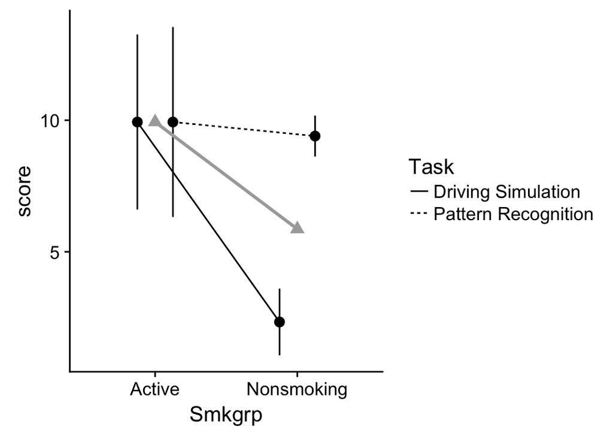

```r
interaction_p +
  stat_summary(aes(x=Smkgrp, y=score, group=1), geom = "point", fun.y = "mean", color="dark grey", size=3, shape=17) +
  stat_summary(aes(x=Smkgrp, y=score, group=1), geom = "line", fun.y = "mean", color="dark grey", size=1)
```

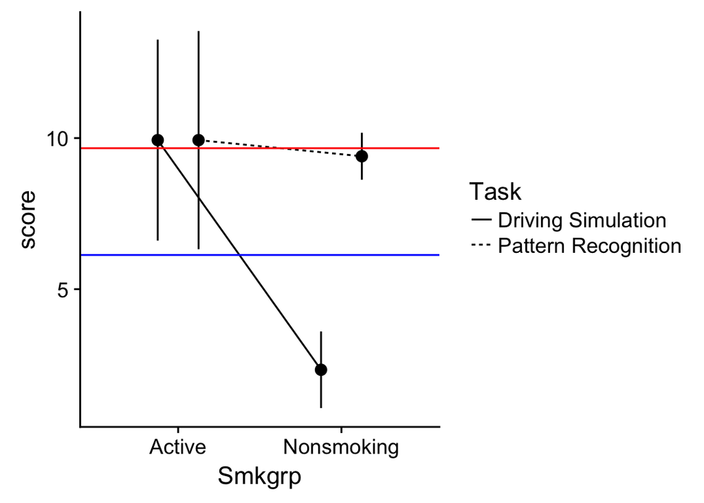

```r
interaction_p +
  geom_hline(yintercept = 9.6667, color="red") +
  geom_hline(yintercept = 6.1333, color="blue")
```

The difference in y-intercepts suggests the possibility of a main effect.

So in summary, I’m guessing from plot I’ve got 2 main effects and an interaction. Let’s test this.

# Running the ANOVA `lm()` method

Now we can run the using the `lm()` method as we have previously done with the One-way ANOVA. The new wrinkle is simply adding our additional IV and interaction terms the formula equation the structural equation:

$$y=IV_1+IV_2+(IV_1*IV_2)$$
where the first and second terms capture our main effects and the third is our interaction. Using our data in `R` this formula becomes:

```r
lm(score~Smkgrp+Task+Smkgrp:Task,data = dataset_2by2) %>% summary.aov()
```

The operator `:` may be understood here as “interaction between”. Note that we can write this same equation in shorthand:

```r
lm(score~Smkgrp*Task,data = dataset_2by2) %>% summary.aov()
```

where the `*` operator tells `R` to examine **all** related main effects and interactions. This is usually the best way to code this, as the long-form becomes unweildy as we increase IVs and combinations of interactions. However, note that if you have planned comparisons you may elect to only specify certain main effects and interactions in log-form.

OK, running the above gives us:

```
##             Df Sum Sq Mean Sq F value  Pr(>F)
## Smkgrp       1  248.1  248.07  11.569 0.00124 **
## Task         1  187.3  187.27   8.733 0.00456 **
## Smkgrp:Task  1  187.3  187.27   8.733 0.00456 **
## Residuals   56 1200.8   21.44
## ---
## Signif. codes:  0 '***' 0.001 '**' 0.01 '*' 0.05 '.' 0.1 ' ' 1
```

# Running the ANOVA in the `afex::aov_ez()` method:

We can also use the `aov_ez` method from the `afex` library. In fact, this might be preferable, as the output gives you most everything you need to report your ANOVA, and in the future this method makes the necessary corrections for you if your data violates certain assumptions needed for ANOVA. While I have been stressing the `lm()` method to re-enforce that ANOVA and linear regression are two sides of the same coin, when performing ANOVA I typically use `afex::aov_ez()` unless I am planning some very complex a priori comparisons in my model (this is rarely the case). With `aov_ez()` we can easily specify the ANOVA model by inputting our parameters into the function. Please note which need to be input as strings (i.e., have “” around them), and which are input as objects or numbers.

One important note before continuing is that this method requires that you have a column that specifies participant number, here I’ll use `PartID`. Since we are running a purely between-design, we need to assign each participant a unique number. If `R` finds instances where `PartID` are the same it will assume that data comes from the same participant (i.e., we have a within-subjects or repeated measures design). For our purposes now, this is easily solved by simply creating a column that runs from 1 to the number of observations in our data. After that we can proceed with the ANOVA:

```r
# create a PartID column and number
dataset_2by2$PartID <- 1:nrow(dataset_2by2)

# run the ANOVA
afex::aov_ez(id = "PartID",dv = "score",data = dataset_2by2,between = c("Smkgrp","Task"),within = NULL,covariate = NULL,observed = NULL,fun_aggregate = NULL,type = 3,factorize = TRUE,check_contrasts = TRUE,return = "afex_aov",anova_table = list(es = "pes", sig_symbols = rep("", 4)))
```

```
## Anova Table (Type 3 tests)
##
## Response: score
##        Effect    df   MSE     F pes p.value
## 1      Smkgrp 1, 56 21.44 11.57 .17    .001
## 2        Task 1, 56 21.44  8.73 .13    .005
## 3 Smkgrp:Task 1, 56 21.44  8.73 .13    .005
```

Note that above I specified every argument in the function. This was not necessary (indeed if you use Rstudio to help you fill this in, you’ll notice that many of the defaults are NULL). A complete write-up of what is going on here may be found by `?afex::aov_ez`.

For now I want to comment on a few of the choices I made. For `type` I selected Type III sum of squares. This is typically the type that we will choose in ANOVA, however see Field, Ch 11, “Jane Superbrain 11.1” for an excellent overview of the different Types of Sum of Squares and when to use different values. Also you’ll notice I made a few adjustments in my `anova_table` output via `list()`. These were to get the table to output partial eta-squared `es="pes"` (it defaults to general eta-squared) and to remove the stars and asterisks that are typically used to convey significance. The latter isn’t simple an aesthetic choice. Removing these will be useful to us in the near future.

# More examples

### Running the ANOVA

I’m going to use `afex::aov_ez()`:

```r
# create a PartID column and number
dataset$PartID <- 1:nrow(dataset)

# run the ANOVA
afex::aov_ez(id = "PartID",dv = "score",data = dataset,between = c("Smkgrp","Task"),type = 3, return = "afex_aov",anova_table = list(es = "pes", sig_symbols = rep("", 4)))
```

```
## Anova Table (Type 3 tests)
##
## Response: score
##        Effect     df    MSE      F pes p.value
## 1      Smkgrp 2, 126 107.83   8.41 .12   .0004
## 2        Task 2, 126 107.83 132.90 .68  <.0001
## 3 Smkgrp:Task 4, 126 107.83   2.94 .09     .02
```

### APA plotting

For the plot I’m going to give examples of presenting the data in line plot, bar plot, and box plot form. Which you choose depends on what you want to convey, and how complex the plot becomes.

#### Line plot with 95% CI bars

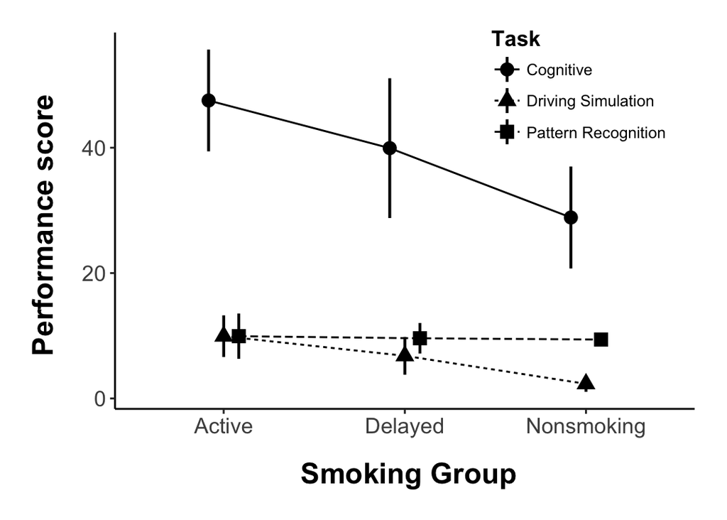

```r
# setting original parameters
p <- ggplot2::ggplot(data = dataset, mapping=aes(x=Smkgrp,y=score,group=Task))

# making a basic line plot
line_p <- p + stat_summary(geom="pointrange",fun.data = "mean_cl_normal", size=0.75, position=position_dodge(.25), aes(shape=Task)) +
  stat_summary(geom = "line", fun.y = "mean", position=position_dodge(.25), aes(linetype=Task))

# adding APA elements
line_p <- line_p + theme_classic() + theme(
    axis.title = element_text(size = 16, face = "bold", lineheight = .55),
    axis.text = element_text(size = 12),
    legend.title = element_text(size = 12, face = "bold"),
    legend.position = c(.8,.85)) +
  xlab("\n Smoking Group") +
  ylab ("Performance score \n") +
  theme(plot.margin=unit(c(.25,.25,.25,.25),"in"))

show(line_p)
```

A few notes:

- I elected to dodge the mean points. I find this to be clearer as I don’t have to worry about my overlapping error bars (this would be true even if I have the caps on the bars as well).
- I also differentiated each task group by both line and shape. In reality this is redundant, but I feel that it makes the differences in groups easier to distinguish with a quick glance. Note that I could have also chosen color, but with print APA color should only be chosen when using 2 or three shades of grey, and typically as a last resort.

#### Box plot

Here, let’s do the same with box plots:

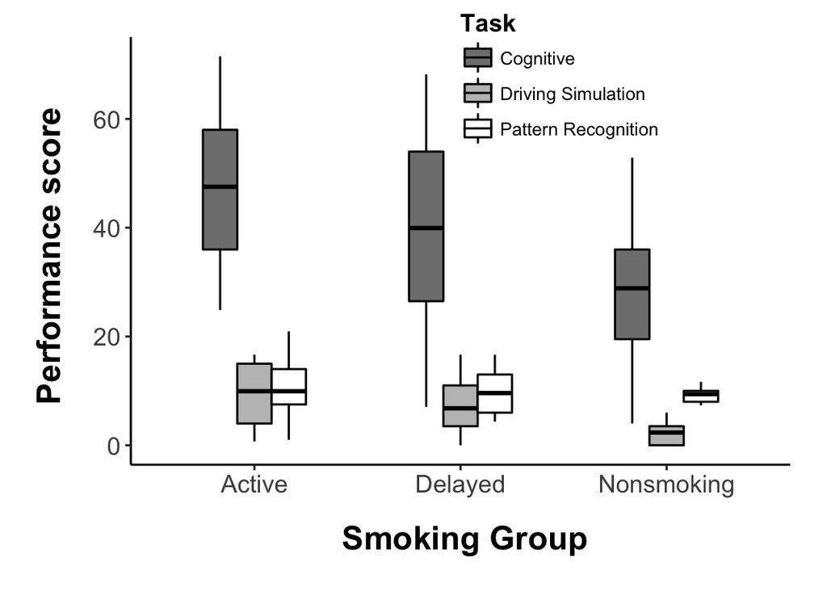

```r
# setting original parameters
p <- ggplot2::ggplot(data = dataset, mapping=aes(x=Smkgrp,y=score,group=Task))

# note that I'm using the functions I've created in the previous boxplot example
box_p <- p +
  stat_summary(fun.data = box_mean, size=.5, color="black", geom="boxplot", position="dodge", aes(fill=Task, width=.5))

# APA-ify
box_p <- box_p + theme_classic() + theme(
    axis.title = element_text(size = 16, face = "bold", lineheight = .55),
    axis.text = element_text(size = 12),
    legend.title = element_text(size = 12, face = "bold"),
    legend.position = c(.65,.9)) +
  scale_fill_manual(values = c("grey50","grey75","white")) +
  xlab("\n Smoking Group") +
  ylab ("Performance score \n") +
  theme(plot.margin=unit(c(.25,.25,.25,.25),"in"))

show(box_p)
```

A few notes:

- I decreased the widths of my box plots as otherwise the box plot may feel a little cramped. This was accomplished in the `aes()` call when I constructed the base box plot. (I changed width to 0.5)

#### Bar plot

And finally a bar plot. Remember when making a bar plot, we need to correct for the gap below zero on the y-axis:

```r
# setting original parameters
p <- ggplot2::ggplot(data = dataset, mapping=aes(x=Smkgrp,y=score,group=Task))

# constructing the bar plot:
bar_p <- p +
stat_summary(geom="errorbar", width=.3, fun.data = "mean_cl_normal", level=0.95, position = position_dodge(.9)) +
  stat_summary(geom = "bar",fun.y = "mean",color="black", aes(fill=Task), position=position_dodge(.9))

# adding APA:
bar_p <- bar_p + theme(
    axis.title = element_text(size = 16, face = "bold", lineheight = .55),
    axis.text = element_text(size = 12),
    legend.title = element_text(size = 12, face = "bold"),
    legend.position = c(.6,.85)) +
  scale_fill_manual(values=c("black","grey50","white")) +
  xlab("\n Smoking Group") +
  ylab ("Performance score \n") +
  theme(plot.margin=unit(c(.25,.25,.25,.25),"in")) +
  # fixing y-axis:
  scale_y_continuous(expand = c(0,0)) + expand_limits(y=c(0,25))
```

## 2 × 5 ANOVA (Howell 13.1)

For another example, we can return to the Eysenck data from Howell, Ch 13.1:

```r
dataset <- read.table("https://www.uvm.edu/~dhowell/methods8/DataFiles/Tab13-2.dat", header = T)

# label dummy codes:
dataset$Age <- plyr::mapvalues(dataset$Age,from = c(1,2), to = c("Old","Young")) %>% as.factor()

dataset$Condition <- plyr::mapvalues(dataset$Condition,from = c(1,2,3,4,5), to = c("Counting","Rhyming","Adjective","Imagery","Intentional")) %>% as.factor()

# re-leveling:
dataset$Condition <- factor(dataset$Condition,levels = c("Counting","Rhyming","Adjective","Imagery","Intentional"))

summary(dataset)
```

```
##     Age           Condition      Recall
##  Old  :50   Counting   :20   Min.   : 3.00
##  Young:50   Rhyming    :20   1st Qu.: 7.00
##             Adjective  :20   Median :11.00
##             Imagery    :20   Mean   :11.61
##             Intentional:20   3rd Qu.:15.25
##                              Max.   :23.00
```

### Running the ANOVA

```r
# create a PartID column and number
dataset$PartID <- 1:nrow(dataset)

# run the ANOVA
afex::aov_ez(id = "PartID",dv = "Recall",data = dataset,between = c("Age","Condition"),type = 3, return = "afex_aov",anova_table = list(es = "pes", sig_symbols = rep("", 4)))
```

```
## Anova Table (Type 3 tests)
##
## Response: Recall
##          Effect    df  MSE     F pes p.value
## 1           Age 1, 90 8.03 29.94 .25  <.0001
## 2     Condition 4, 90 8.03 47.19 .68  <.0001
## 3 Age:Condition 4, 90 8.03  5.93 .21   .0003
```

#### Line plot with SE bars

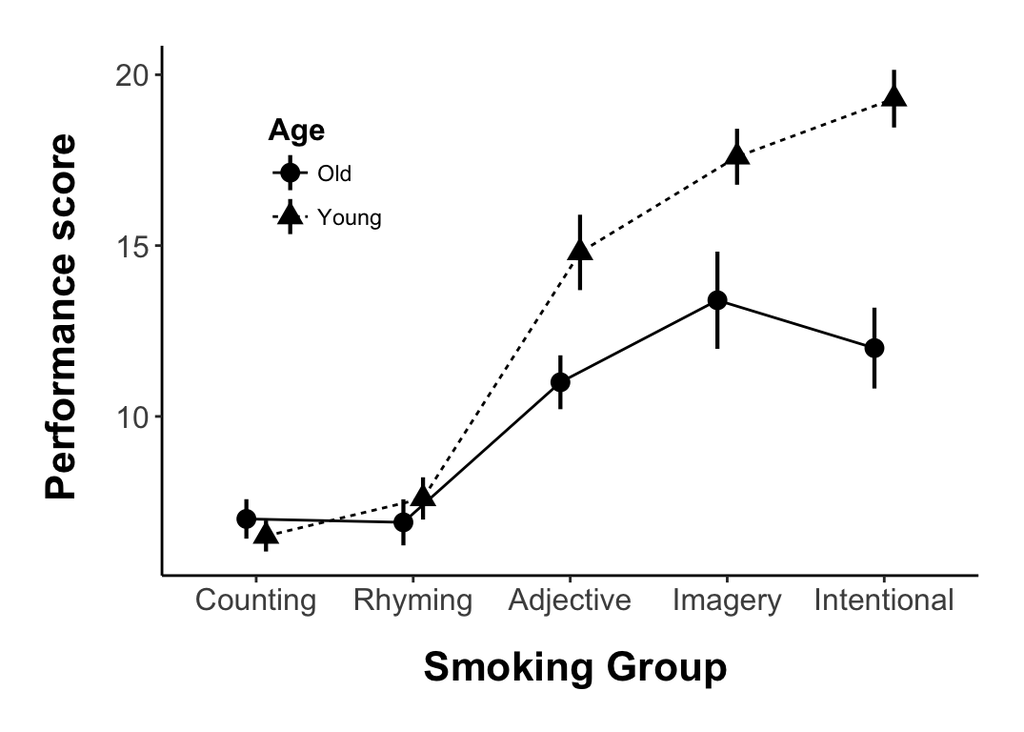

```r
# setting original parameters
p <- ggplot2::ggplot(data = dataset, mapping=aes(x=Condition,y=Recall,group=Age))

# making a basic line plot
line_p <- p + stat_summary(geom="pointrange",fun.data = "mean_se", size=0.75, position=position_dodge(.25), aes(shape=Age)) +
  stat_summary(geom = "line", fun.y = "mean", position=position_dodge(.25), aes(linetype=Age))

# adding APA elements
line_p <- line_p + theme_classic() + theme(
    axis.title = element_text(size = 16, face = "bold", lineheight = .55),
    axis.text = element_text(size = 12),
    legend.title = element_text(size = 12, face = "bold"),
    legend.position = c(.2,.75)) +
  xlab("\n Smoking Group") +
  ylab ("Performance score \n") +
  theme(plot.margin=unit(c(.25,.25,.25,.25),"in"))

show(line_p)
```

We could elect to create bar plots and box plots here as well. One thing to keep in mind is that these plots become more and more cramped as you consider additional IVs and levels as in higher order designs.

## One last example,

```r
dataset_no_inter <- read.table("https://raw.githubusercontent.com/tehjespah/tehjespah.github.io/master/teaching/PSYC7014/datasets/two_factor_ANOVA_no_interaction", header=T)


dataset_no_inter$Lecture <- mapvalues(dataset_no_inter$Lecture, to=c("Phys","Soc","Hist"),from = c(1,2,3)) %>% as.factor()

dataset_no_inter$Presentation <- mapvalues(dataset_no_inter$Presentation, to=c("Comp","Stand"),from = c(1,2)) %>% as.factor()

dataset_no_inter$Presentation <- as.factor(dataset_no_inter$Presentation)
dataset_no_inter$Lecture <- as.factor(dataset_no_inter$Lecture)

summary(dataset_no_inter)
```

```
##  Lecture   Presentation     Score
##  Hist:12   Comp :18     Min.   :13.00
##  Phys:12   Stand:18     1st Qu.:27.75
##  Soc :12                Median :35.00
##                         Mean   :34.81
##                         3rd Qu.:42.00
##                         Max.   :53.00
```

### Running the ANOVA

I’m going to use `afex::aov_ez()`:

```r
# create a PartID column and number
dataset_no_inter$PartID <- 1:nrow(dataset_no_inter)

# run the ANOVA
afex::aov_ez(id = "PartID",dv = "Score",data = dataset_no_inter,between = c("Lecture","Presentation"),type = 3, return = "afex_aov",anova_table = list(es = "pes", sig_symbols = rep("", 4)))
```

```
## Anova Table (Type 3 tests)
##
## Response: Score
##                 Effect    df   MSE     F pes p.value
## 1              Lecture 2, 30 49.09  4.95 .25     .01
## 2         Presentation 1, 30 49.09 31.25 .51  <.0001
## 3 Lecture:Presentation 2, 30 49.09  0.32 .02     .73
```

### Interaction plot

Here we have a case where there is no interaction. Plotting this:

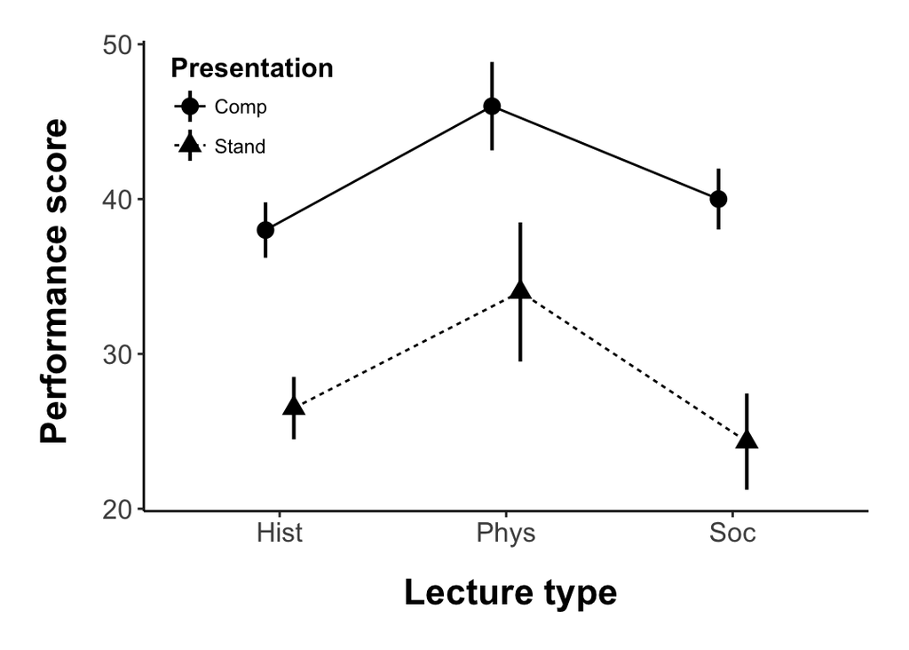

```r
# setting original parameters
p <- ggplot2::ggplot(data = dataset_no_inter, mapping=aes(x=Lecture,y=Score,group=Presentation))

# making a basic line plot
line_p <- p + stat_summary(geom="pointrange",fun.data = "mean_se", size=0.75, position=position_dodge(.25), aes(shape=Presentation)) +
  stat_summary(geom = "line", fun.y = "mean", position=position_dodge(.25), aes(linetype=Presentation))

# adding APA elements
line_p <- line_p + theme_classic() + theme(
    axis.title = element_text(size = 16, face = "bold", lineheight = .55),
    axis.text = element_text(size = 12),
    legend.title = element_text(size = 12, face = "bold"),
    legend.position = c(.15,.85)) +
  xlab("\n Lecture type") +
  ylab ("Performance score \n") +
  theme(plot.margin=unit(c(.25,.25,.25,.25),"in"))

show(line_p)
```

# Interaction v. no interaction

Why is the fact that there is no interaction here important? Of all of the examples that we’ve covered to this point, the last example was the only example that we can trust our main effects at face value. This re-enforces the point I made earlier: **Look at your interaction FIRST!!!** Consider what the interaction means— that your observed main effects are contingent on certain conditions. If you have a significant interaction, you must run **simple effects** analysis to elucidate these contingencies. For example, looking at our very first example:

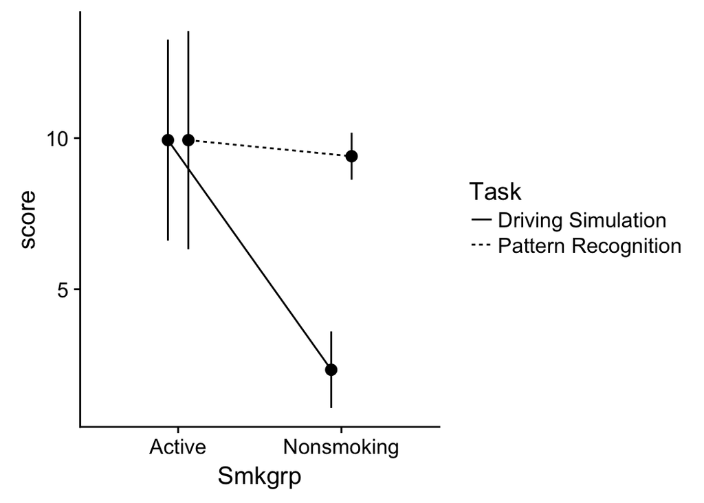

```r
p <- interaction_p <- ggplot2::ggplot(data = dataset_2by2, mapping=aes(x=Smkgrp,y=score,group=Task))

interaction_p <- interaction_p + stat_summary(geom="pointrange",fun.data = "mean_cl_normal", position=position_dodge(.25)) +
  stat_summary(geom = "line", fun.y = "mean", position=position_dodge(.25), aes(linetype=Task)) +
  theme_cowplot()

show(interaction_p)
```

```r
# create a PartID column and number
dataset_2by2$PartID <- 1:nrow(dataset_2by2)

# run the ANOVA
afex::aov_ez(id = "PartID",dv = "score",data = dataset_2by2,between = c("Smkgrp","Task"),within = NULL,covariate = NULL,observed = NULL,fun_aggregate = NULL,type = 3,factorize = TRUE,check_contrasts = TRUE,return = "afex_aov",anova_table = list(es = "pes", sig_symbols = rep("", 4)))
```

```
## Anova Table (Type 3 tests)
##
## Response: score
##        Effect    df   MSE     F pes p.value
## 1      Smkgrp 1, 56 21.44 11.57 .17    .001
## 2        Task 1, 56 21.44  8.73 .13    .005
## 3 Smkgrp:Task 1, 56 21.44  8.73 .13    .005
```

The ANOVA reveals a main effect for smoking group. However, looking at the plot, we know that this is not the entire story. That is, the means change from one smoking group to another for the Driving simulation task, but not for the Pattern recognition group—our main effect for Smoking group **depends** on task. This is what I mean by “you can’t trust your main effects when you have an interaction”—they don’t tell the entire story.

### what to do if you DON’T have an interaction

If you don’t have an interaction, you may simply proceed to run post-hoc analyses on any significant main effects in the manner you would with a One-way ANOVA. Easy, peasy, right. One thing to note, you need to make the appropriate multiple comparison corrections. The easy way to do this is to perform a Bonferroni correction on the number of post-hoc comparisons that you intend. For example, returning to our data with no interaction:

```r
# create a PartID column and number
dataset_no_inter$PartID <- 1:nrow(dataset_no_inter)

# run the ANOVA
afex::aov_ez(id = "PartID",dv = "Score",data = dataset_no_inter,between = c("Lecture","Presentation"),type = 3, return = "afex_aov",anova_table = list(es = "pes", sig_symbols = rep("", 4)))
```

```
## Anova Table (Type 3 tests)
##
## Response: Score
##                 Effect    df   MSE     F pes p.value
## 1              Lecture 2, 30 49.09  4.95 .25     .01
## 2         Presentation 1, 30 49.09 31.25 .51  <.0001
## 3 Lecture:Presentation 2, 30 49.09  0.32 .02     .73
```

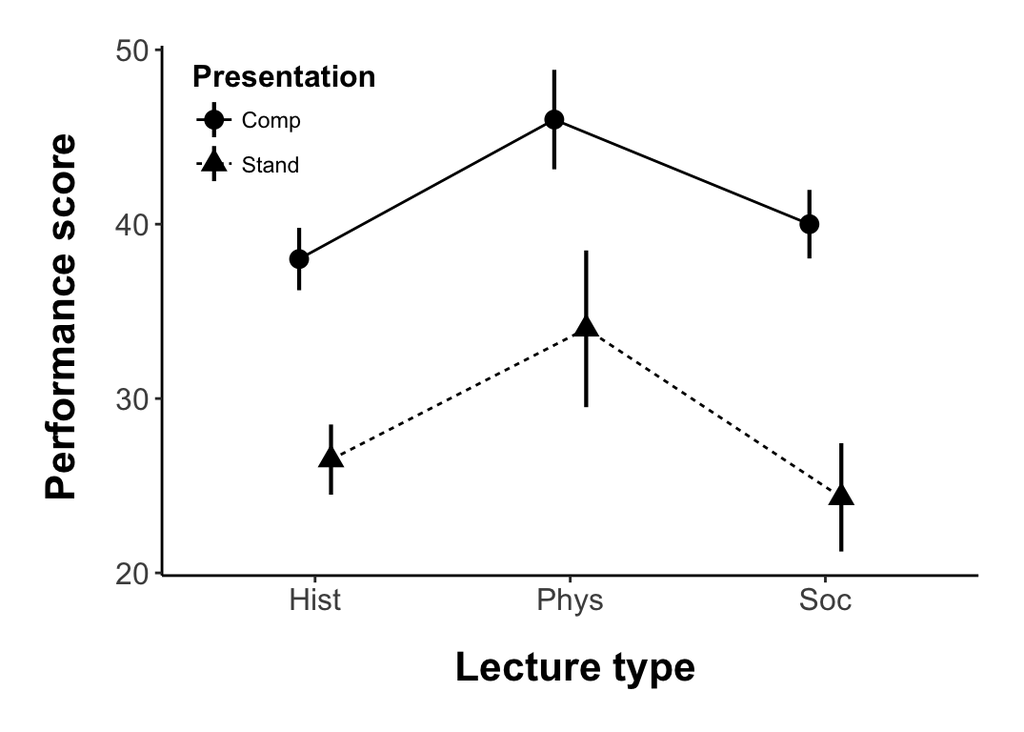

```r
# setting original parameters
p <- ggplot2::ggplot(data = dataset_no_inter, mapping=aes(x=Lecture,y=Score,group=Presentation))

# making a basic line plot
line_p <- p + stat_summary(geom="pointrange",fun.data = "mean_se", size=0.75, position=position_dodge(.25), aes(shape=Presentation)) +
  stat_summary(geom = "line", fun.y = "mean", position=position_dodge(.25), aes(linetype=Presentation))

# adding APA elements
line_p <- line_p + theme_classic() + theme(
    axis.title = element_text(size = 16, face = "bold", lineheight = .55),
    axis.text = element_text(size = 12),
    legend.title = element_text(size = 12, face = "bold"),
    legend.position = c(.15,.85)) +
  xlab("\n Lecture type") +
  ylab ("Performance score \n") +
  theme(plot.margin=unit(c(.25,.25,.25,.25),"in"))

show(line_p)
```

We need to test for differences in both the `Lecture` and `Presentation` main effects.

- Presentation: This one is easy. We only have two levels of `Presentation`, so the omnibus `Ftest` tells us that our two groups are different. Nothing else to do here other than note which mean (Computer v. Standard) is greater than the other.
- Lecture: We have three levels of lecture, so were are going to need to run a post-hoc analysis. In this case, we may call upon our old standbys, Bonferroni, Tukey, and REGWQ. For example, a `pairwise.t.test` with a “bonferroni” adjustment reveals:

```r
pairwise.t.test(dataset_no_inter$Score,dataset_no_inter$Lecture,p.adjust.method = "bonferroni")
```

```
##
##  Pairwise comparisons using t tests with pooled SD
##
## data:  dataset_no_inter$Score and dataset_no_inter$Lecture
##
##      Hist Phys
## Phys 0.17 -
## Soc  1.00 0.16
##
## P value adjustment method: bonferroni
```

You may now be confused that the post hoc for `Lecture` revealed no differences even though we had an overall main effect. Don’t worry, these two do not contradict one another. The main effect is examining the overall trend in the data (think of the slope of the regression line) while the post-hoc pairwise comparisons are examining differences in means. In some cases the two are in agreement with one another. In others they don’t match up. In this case you may simply say that “while the main effect for Lecture type indicated an overall trend that performance was different by lecture, pairwise comparisons revealed no significant differences between individual lecture types.”

That said… remember that the Bonferroni adjustment is the most conservative of the three. Let’s see what happends if we run a Tukey HSD. To run a Tukey remember that you need the ANOVA model to be saved to an object. One thing to consider is that when we ran the `afex::aov_ez()` model we returned it as an `afex_aov` object

```r
afex::aov_ez(id = "PartID",dv = "Score",data = dataset_no_inter,between = c("Lecture","Presentation"),type = 3, return = "afex_aov",anova_table = list(es = "pes", sig_symbols = rep("", 4)))
```

```
## Anova Table (Type 3 tests)
##
## Response: Score
##                 Effect    df   MSE     F pes p.value
## 1              Lecture 2, 30 49.09  4.95 .25     .01
## 2         Presentation 1, 30 49.09 31.25 .51  <.0001
## 3 Lecture:Presentation 2, 30 49.09  0.32 .02     .73
```

However, the `agricolae` package prefers the ANOVA models to be in the form of an `lm()` or `aov` object. This can be done in `afex` by simply changing `return="afex_aov"` to `return="aov"`.

```r
aov.model <- afex::aov_ez(id = "PartID",dv = "Score",data = dataset_no_inter,between = c("Lecture","Presentation"),type = 3, return = "aov",anova_table = list(es = "pes", sig_symbols = rep("", 4)))

# Tukey (Lecture main effect):
agricolae::HSD.test(aov.model, trt="Lecture",group = F,console = T)
```

```
##
## Study: aov.model ~ "Lecture"
##
## HSD Test for Score
##
## Mean Square Error:  49.09444
##
## Lecture,  means
##
##         Score       std  r Min Max
## Hist 32.25000  7.472678 12  20  45
## Phys 40.00000 10.795622 12  18  53
## Soc  32.16667 10.187634 12  13  47
##
## Alpha: 0.05 ; DF Error: 30
## Critical Value of Studentized Range: 3.48642
##
## Comparison between treatments means
##
##              difference pvalue signif.         LCL        UCL
## Hist - Phys -7.75000000 0.0289       * -14.8018857 -0.6981143
## Hist - Soc   0.08333333 0.9995          -6.9685524  7.1352190
## Phys - Soc   7.83333333 0.0270       *   0.7814476 14.8852190
```

It appears that our Tukey does reveal differences between means, reinforcing that it is often the preferred test.

### what to do if you DO have an interaction

Well, for this week, you stop. More to come soon about where to go from here.